# CS 372/472 & LRN_SCI 372/472

Designing Models

Prof. Connor Bain

connor.bain@northwestern.edu

April 28, 2026

## Logistical Stuff

**Exercise 5**

- Is due on SUNDAY at 11:59pm via Canvas.
- Asks you to continue thinking about the Final Project for the course.

**Class on May 19th**

We will NOT have class on May 19th

## Schelling’s Model - The Rules

### SETUP

- *Some* `patches`:
  - I `sprout` a turtle with a 50% chance of being `red` and a 50% chance of being `blue`.

### GO (at each clock tick)

- Each `turtle`:
  - I `count` the total number of `turtles` on the `patches` neighboring mine.
  - I `count` the number of `turtles` who are the same `color` as `myself` on the `patches` neighboring mine.
  - If the ratio of same-color `turtles` to total `turtles` is less than the `%-similar-wanted`, I move to a random empty `patch`.
    - Then, I move to a new empty spot.

## DLA - The Rules

### SETUP

- Center `patch`:
  - I turn green and act as the seed of the aggregate.
- Spawn some number of turtles across the world.

### GO (at each clock tick)

- Each `turtle`:
  - Wiggles around randomly (i.e. Brownian motion).
  - If I touch a `green patch`, I turn the patch I’m on green and die.

## Why study DLA?

- It can model a wide variety of physical processes (e.g. cloud formation, snowflakes, soot, smoke, dust).
- But it can also be used to model other phenomenon:
  - The growth of cities. (Fotheringham et al. 1989)
  - Barabasi would later contrast it to the preferential attachment model of network growth, which is more appropriate for modeling the growth of social networks. (Barabási and Albert 1999)
  - Ideas where *physical space* is the bottleneck for growth.

## Purposes of Modeling

- Description
- Explanation
- Experimentation (or Prediction)
- Providing sources of analogy
- Communication / education
- Providing focal objects for dialogue
- Thought experiments

## Designing and Building a Model

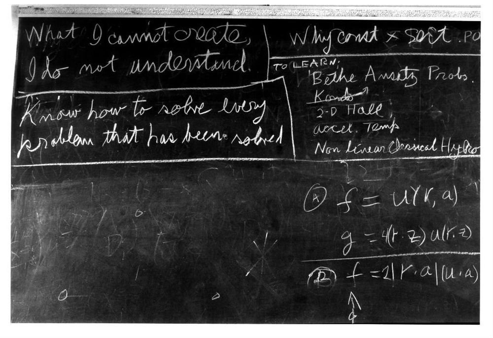

Feynman’s Chalkboard

# Example Question - *How do the population levels of two species change over time when they coexist in a shared habitat?*

## Dimension 1 - Modeling approach

### Phenomena-based Modeling

- Are we trying to reproduce a specific reference pattern?
- Almost as if it’s *equation-based modeling*, but instead of writing down equations, we’re writing down rules for agents to follow.

### Exploratory Modeling

- Are we experimenting with rule-sets to see what kinds of patterns they produce?
- Like the Game of Life, what sorts of patterns emerge from the rule sets?

### The Gray Area

- Of course, we might see elements of both in the same model.

## Dimension 2 - Modeling questions

### At one end…

- *“How does a colony of ants forage for food?”*

### At the other end…

- *“I’m interested in modeling ant behavior”*

## Dimension 3 - Modeling direction

### Top-down modeling

You’ve already worked out the: * agents * environment *before writing a single line of code*

### Bottom-up modeling

You choose a domain and start programming some rules, and then see what patterns emerge, and then iterate on the rules.

## Isle Royale as a Reference Pattern

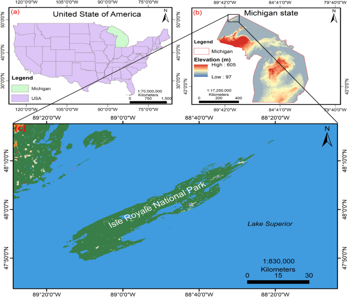

Isle Royale

# The ABM Design Principle

## The ABM Design Principle

1. Begin with the **simplest possible** set of agents and rules of behaivor tha can be used to explore the system you want to model.

> The supreme goal of all theory is to make the irreducible basic elements as simple and as few as possible without having to surrender the adequate representation of a single datum of experience. (Einstein 1934)
2. Always have your question in mind, which means not adding anything to your model that does not help you in answering your question

> “All models are wrong, but some are useful.” (Box 1979)

## Reference Pattern

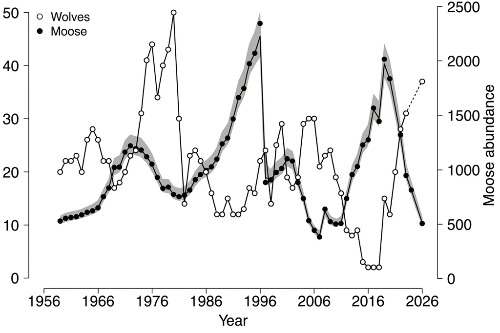

## Isle Royale as a Reference Pattern

- They’ve been following the population’s since [1959](https://www.isleroyalewolf.org/timeline)
- It’s in [the news](https://apnews.com/article/isle-royale-wolf-population-annual-survey-3df2cc68d387a9d43ba9b36da48a28ed)!

## When to ABM? (or when not to EBM)

- Are there a large number of interacting agents?
- Do the interactions between agents matter for the phenomenon you’re trying to model?
- Do you care about the heterogeneity of the agents?
- Does spatial structure of the environment affect the outcome?
- Is the phenomenon you’re trying to model dynamic and evolving over time?

## Process

- What are the agents?
- What are their properties?
- What are their behaviors?
- What is a time step?
- What are the parameters we want to start with?
- What are the measures we want to track?

## What are the agents?

### Concentrate on the entities which are *most* relevant to our question.

### Carefully consider the granularity of the agent.

- Do we want to model individual animals, or do we want to model groups of animals?
- If we model grass, do we want to model individual blades of grass, or do we want to model clumps of grass?

## Design Spec

- Moving Agent Types: wolves & sheep
- Moving Agent Properties: energy, location, and heading
- Moving Agent Behaviors: move, die, reproduce, eat-sheep (wolves only), eat-grass (sheep only)
- Environmental Agent Types: grass
- Environmental Agent Properties: location, regrowth time
- Environmental Agent Behaviors: regrow
- Model Parameters: Number of sheep & wolves at start, movement cost, energy gain from eating, grass regrowth rate
- Measures: population levels of wolves and sheep over time

## Design Spec (cont.)

- Time Step:
  - Agents move
  - Agents eat
  - Agents die
  - Agents reproduce
  - Grass regrows

# Let’s build it!

# Student Presentation - Jared & Sadaqat - Simple Economy Extensions from Exercise 3

# Final Project Details

## Overview

**Goal**: The goal of the project is to design, implement, and evaluate a substantial agent-based model of an emergent phenomenon that is of interest to you.

## Deliverables

**What’s Due**:

- A completed agent-based model(s) implemented in NetLogo at the quality-level of those in the NetLogo Model’s Library.
- A final paper describing your model, the design process, and the results of your evaluation.
  - For 372 students, this will be structured as a lab report (on the order of 5 to 7 pages)
  - For 472 students, this will be structured as a research paper for a conference in your field (on the order of 8 to 10 pages)
- A final “firehose presentation slide” for your model that you will present to the class on the next to last day of class.
- A final “poster” for your model that you will present to the class (and the greater NU community) on the last day of class.

## Model Details

1. The code should be readable (e.g., well structured, well written, and well commented) and close-to-understandable by a person who is becoming familiar with NetLogo.
2. The Info tab should include all the main parts in the NetLogo Models Library. It should succinctly and accurately describe the phenomenon being modeled. A reader who does not have any background in the subject should be able to at least garner some understanding of what is going on.
3. The interface should be *intuitive* and it should be possible to use the model (at least tinker with it) without having to refer to the Info tab immediately.
4. Refer to the [NetLogo Style Guide](https://github.com/NetLogo/models/wiki/NetLogo-Style-Guide) for guidance.

## Additional Requirement for 472

1. Create additional related, but substantially distinct models
2. Incorporate some other advanced NetLogo feature (such as interfacing with hardware or using the LevelSpace, GIS, Python, or Network extension) into a complementary model
3. Create a HubNet activity that complements the NetLogo model

## Paper / Report Details

This is the final “evolution” of the document that starts as your Final Project Design Proposal which we will discuss in detail next week:

- A high-level picture overview
- description of what can be learned
- motivation/rationale for the project, description of rules/model implementation

But it should be polished and also contain substantial sections describing your results and analysis of the model.

> For 372 students this will look more like a lab report, and for 472 students this will look more like a research paper for a conference in your field.

## Analysis Possibilities

- Exploration of parameter space and possible regimes
- Comparison with real world data / reference pattern
- Empirical analysis
  - Report on an actual case of someone (or some group) actually using your model.

> 400-level student papers are expected to be both more grounded in the relevant academic literature and more rigorous/extensive in the model analysis, at a standard that could put it on a trajectory towards publication.

## References

Barabási, Albert-László, and Réka Albert. 1999. “Emergence of Scaling in Random Networks.” *Science* 286 (5439): 509–12.

Box, George EP. 1979. “Robustness in the Strategy of Scientific Model Building.” In *Robustness in Statistics*. Elsevier.

Einstein, Albert. 1934. “On the Method of Theoretical Physics.” *Philosophy of Science* 1 (2): 163–69.

Fotheringham, A. Stewart, Michael Batty, and Paul A. Longley. 1989. “DIFFUSION‐LIMITED AGGREGATION AND THE FRACTAL NATURE OF URBAN GROWTH.” *Papers in Regional Science* 67 (1): 55–69. https://doi.org/https://doi.org/10.1111/j.1435-5597.1989.tb01182.x.

Schelling, Thomas C. 1978. *Micromotives and Macrobehavior*. W. W. Norton & Company.